# 10b_distribution_fitting_disc_202510

## Tarea semana 2: Modelado de datos discretos

### Grafos

- Un grafo es una colección de nodos, ó vértices (vertex) interconectados por ramas (edge):

[figure not shown]

- Uno de los modelos más importantes en teoría de grafos y redes complejas es el de un grafo aleatorio.
  - Las grandes estructuras complejas que se encuentran en la naturaleza suelen estar formadas por interacciones individuales no correlacionadas entre un gran número de sus constituyentes, por lo que no sorprende que los grafos aleatorios proporcionen buenos modelos para muchas de ellas.
  - Aunque las estructuras hechas por el hombre son el resultado de un diseño racional (o así lo deseamos), a menudo exhiben suficiente "aleatoriedad", ya sea porque su estructura se desarrolló con el tiempo (como la World-Wide-Web), o porque copian un modelo anterior de red existente (por ejemplo, red aeroportuaria, red eléctrica) o están sujetas a restricciones aleatorias o de otro tipo (por ejemplo, geográficas).
  - Los grafos aleatorios con las características adecuadas pueden servir como modelos útiles para la evolución y el funcionamiento de muchas estructuras artificiales complejas.
  - Si desea conocer más acerca de grafos puede revisar las siguentes lecturas no obligatorias:
    - https://www.math.tugraz.at/~kang/papers/Kang-Intelligencer.pdf
    - https://epubs.siam.org/doi/pdf/10.1137/S003614450342480

### Problema: Discrete Logistics

- La empresa Discrete Logistics ha realizado un análsis de su cadena logística en una región del país donde opera.
- Ha recopilado la información de 50 centros logísticos y registra el número de otros centros con los que tiene conexión directa (envío y recibo de paquetería).
  - La red de Discrete Logistic puede considerarse una red aleatoria.
  - El número de conexiones que tiene cada centro se conoce como **grado del nodo** en teoría de grafos.
    - Esto está registrado en la variable *Enlaces* para cada uno de los 50 centros.

**Archivo de datos:**

- DL_data.csv
- Lea el archivo csv.

```
import pandas as pd
import seaborn as sns

data = pd.read_csv("../data/DL_data.csv")  # si la estructura es la del repositorio de GitHub

# si está trabajando en local y el archivo de datos y el notebook están en el mismo directorio
# data = pd.read_csv("DL_data.csv")

# También puede leer el archivo desde el repositorio de GitHub.
#data = pd.read_csv("https://raw.githubusercontent.com/marsgr6/EN-online/8a1cee296279c274d8f05f3905fce97c1f7636a2/data/DL_data.csv")

data.head()
```

|  | Centro | Enlaces |
| --- | --- | --- |
| 0 | 1 | 5 |
| 1 | 2 | 6 |
| 2 | 3 | 5 |
| 3 | 4 | 8 |
| 4 | 5 | 5 |

- De acuerdo a la teoría de grafos, la distribución del grado de los nodos en una red aleatoria se puede modelar como una variable aleatoria de Poisson $X\sim Poisson(\lambda = n\times p)$, donde $n$ es el número de nodos y $p$ la probabilidad de que exista una conexión entre cualquier pareja de nodos.
  - En nuestro estudio se ha determinado que estos valores son $n=50$, $p=0.1$ para la red de Discrete Logistics.
    - Es decir el grado de la red puede ser modelado con la siguiente distribución $X\sim Poisson(\lambda = 5)$.
- Discrete Logistics está interesado en reconfigurar su red logística y quiere identificar los centros con pocas conexiones que eventualmente pueden ser cerrados.

1.**(1 pt)** Cuál es la distribución del grado de los centro logísticos.

- Escriba el código Python para replicar el gráfico a continuación.
  - El diagrama de barras es la distribución de la variable **Enlaces**.
  - La curva roja representa la distribución $X\sim Poisson(\lambda = 5)$.

[figure not shown]

2.**(2 pt)** Cuál es la probabilidad de que un centro cualquiera tenga 3 o menos conexiones.

- De acuerdo a los valores observados.
- De acuerdo a la distribución de Poisson $X\sim Poisson(\lambda = 5)$.
  - Responda usando la implementación en Python de Poisson.

3.**(1 pt)** Cuál es la probabilidad de que un nodo tenga entre 4 y 6 conexiones.

- Responda usando la implementación en Python de Poisson.

4.**(1 pt)** Replique el histograma acumulado y la función de distribución acumulada para la distritución de Poisson:

[figure not shown]

5.**(2 pt)** Responda usando la CDF:

- Cuál es la probabilidad de que un centro cualquiera tenga 3 o menos conexiones
- Cuál es la probabilidad de que un nodo tenga entre 4 y 6 conexiones.

6.**(1 pt)** Calcule el valor esperado y varianza de la distribución analítica, compare con la media y varianza muestral.

7.**(2 pt)** Discuta qué tan adecuada considera esta distribución para modelar nuestros datos observados.

### Modelado de datos (ajuste de distribuciones)

El ajuste de distribuciones, en el contexto de estadísticas y análisis de datos, se refiere al proceso de encontrar el modelo de distribución que mejor se ajusta a un conjunto de datos observado. En otras palabras, consiste en identificar la función de probabilidad que describe de manera óptima la variabilidad y la estructura de los datos recopilados.

Los pasos comunes en el ajuste de distribuciones incluyen:

1. **Selección del Modelo:** Se elige un tipo específico de distribución (por ejemplo, normal, exponencial, logística) que se presume podría describir la variabilidad de los datos.
2. **Estimación de Parámetros:** Se estiman los parámetros de la distribución seleccionada para que se ajusten mejor a los datos observados. Los parámetros pueden incluir la media, la desviación estándar, la tasa de éxito (en el caso de distribuciones binomiales), entre otros, dependiendo del tipo de distribución.
3. **Validación del Ajuste:** Se realizan pruebas estadísticas para evaluar cuán bien se ajusta la distribución propuesta a los datos reales. Esto podría incluir pruebas de bondad de ajuste, como la prueba de Kolmogorov-Smirnov o la prueba de chi-cuadrado.
4. **Iteración si es Necesario:** Si el ajuste inicial no es satisfactorio, se pueden probar diferentes distribuciones o se puede ajustar la estrategia de ajuste de parámetros para mejorar la calidad del ajuste.

El ajuste de distribuciones es fundamental en diversas áreas, como la inferencia estadística, la modelización de datos financieros, la simulación y en general, en cualquier situación en la que se busque caracterizar la variabilidad de los datos mediante una distribución probabilística.

**Objetivos del Ajuste de Distribuciones:**

1. **Descripción de Datos:** Proporcionar una descripción resumida y comprensible de un conjunto de datos mediante la identificación de la distribución de probabilidad que mejor se ajusta a ellos.
2. **Inferencia Estadística:** Facilitar la inferencia estadística al modelar los datos observados con distribuciones conocidas, lo que permite realizar predicciones y estimaciones sobre la población subyacente.
3. **Simulación:** Permitir la generación de datos sintéticos que sigan la misma distribución que los datos observados, lo que es útil para realizar simulaciones y evaluar escenarios hipotéticos.
4. **Análisis de Riesgos y Pérdidas:** En contextos financieros, el ajuste de distribuciones se utiliza para modelar la variabilidad de los rendimientos, pérdidas y otros factores relacionados con el riesgo, ayudando en la toma de decisiones y la gestión de riesgos.
5. **Detección de Anomalías:** Identificar valores atípicos o anomalías en los datos al comparar la distribución ajustada con las observaciones reales.
6. **Optimización de Procesos:** En ingeniería y manufactura, el ajuste de distribuciones puede ayudar a comprender y mejorar procesos mediante la modelización de variables críticas.

**Aplicaciones del Ajuste de Distribuciones:**

1. **Finanzas:** Modelar la variabilidad de los rendimientos de activos financieros para evaluar riesgos y rendimientos esperados.
2. **Calidad y Procesos Industriales:** Identificar patrones de variabilidad en variables de proceso para mejorar la calidad y eficiencia.
3. **Ciencias de la Salud:** Ajustar distribuciones a datos médicos para entender la distribución de características clínicas y epidemiológicas.
4. **Meteorología:** Modelar la distribución de eventos climáticos, como precipitaciones, temperaturas o velocidades del viento, para mejorar la predicción meteorológica.
5. **Investigación de Operaciones:** Utilizar distribuciones ajustadas en modelos de simulación para analizar y optimizar sistemas complejos.
6. **Estudios de Mercado:** Comprender la distribución de variables relevantes en estudios de mercado para la toma de decisiones empresariales.
7. **Fiabilidad y Mantenimiento:** Modelar la vida útil de equipos y sistemas para planificar estrategias de mantenimiento y garantizar la confiabilidad.

En resumen, el ajuste de distribuciones es una herramienta versátil con aplicaciones en diversas disciplinas, proporcionando una manera efectiva de entender, modelar y utilizar datos en la toma de decisiones y análisis de diferentes fenómenos.

```python
# Importar librerías
import pandas as pd
import seaborn as sns
import matplotlib.pyplot as plt
import numpy as np

# También puede leer el archivo desde el repositorio de GitHub.
data = pd.read_csv("https://raw.githubusercontent.com/marsgr6/EN-online/8a1cee296279c274d8f05f3905fce97c1f7636a2/data/DL_data.csv")

data.head()
```

|  | Centro | Enlaces |
| --- | --- | --- |
| 0 | 1 | 5 |
| 1 | 2 | 6 |
| 2 | 3 | 5 |
| 3 | 4 | 8 |
| 4 | 5 | 5 |

```python
# Extraer solo la columna (variable) a modelar
enlaces = data['Enlaces']

# Valores únicos observados para la variable y sus frecuencias
x_obs, f_obs = np.unique(enlaces, return_counts=True)
# Agregamos el 10 que no aparece en los datos con frecuencia 0
x_obs = np.insert(x_obs, -1, 10)  # número de conexiones (grado del nodo)
# insertamos 0 en f_obs
f_obs = np.insert(f_obs, -1, 0)

# Calculamos las frecuencias relativas ("probabilidad" observada)
px_obs = f_obs/f_obs.sum()
# Calculamos las frecuencias acumuladas
Fx_obs = px_obs.cumsum()

o_data = pd.DataFrame({'x_obs': x_obs, 'f_obs': f_obs, 'prob_f_rel': px_obs, 'Fx_obs': Fx_obs})
o_data
```

|  | x_obs | f_obs | prob_f_rel | Fx_obs |
| --- | --- | --- | --- | --- |
| 0 | 1 | 1 | 0.02 | 0.02 |
| 1 | 2 | 2 | 0.04 | 0.06 |
| 2 | 3 | 4 | 0.08 | 0.14 |
| 3 | 4 | 12 | 0.24 | 0.38 |
| 4 | 5 | 11 | 0.22 | 0.60 |
| 5 | 6 | 8 | 0.16 | 0.76 |
| 6 | 7 | 5 | 0.10 | 0.86 |
| 7 | 8 | 4 | 0.08 | 0.94 |
| 8 | 9 | 2 | 0.04 | 0.98 |
| 9 | 10 | 0 | 0.00 | 0.98 |
| 10 | 11 | 1 | 0.02 | 1.00 |

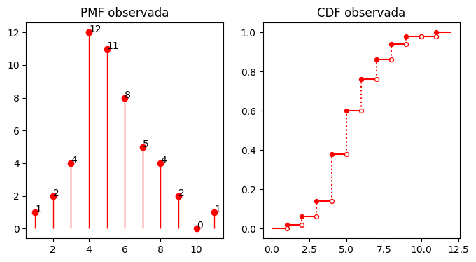

```python
def plot_pmf(x, pmfx, ax=None):
    if ax is None: fig, ax = plt.subplots(1, 1)
    # https://matplotlib.org/api/_as_gen/matplotlib.axes.Axes.vlines.html
    ax.vlines(x, 0, pmfx, colors='r', linestyles='-', lw=1)  # líneas verticales
    ax.plot(x, pmfx, 'ro', label='Pmf')  # puntos sobre las lineas verticales
    for xi, fxi in zip(x, pmfx):
        ax.text(xi, fxi, str(fxi))  # Imprimimos el valor de fx (PMF)


def plot_cdf(rvs_range, cdf_prob, ax=None):
    yn = np.insert(cdf_prob, 0, 0)

    if ax is None:
        fig, ax = plt.subplots()
        ax.set_facecolor('white')

    # https://matplotlib.org/api/_as_gen/matplotlib.axes.Axes.hlines.html
    ax.hlines(y=yn, xmin=rvs_range[:-1], xmax=rvs_range[1:],
              color='red', zorder=1)

    # https://matplotlib.org/api/_as_gen/matplotlib.axes.Axes.vlines.html
    ax.vlines(x=rvs_range[1:-1], ymin=yn[:-1], ymax=yn[1:], color='red',
              linestyle='dotted', zorder=1)

    ax.scatter(rvs_range[1:-1], cdf_prob, color='red', s=18, zorder=2)
    ax.scatter(rvs_range[1:-1], yn[:-1], color='white', s=18, zorder=2,
               edgecolor='red')


fig, ax = plt.subplots(1, 2, figsize=(8,4))

plot_pmf(o_data.x_obs, o_data.f_obs, ax[0])
ax[0].set_title("PMF observada")
x = np.arange(x_obs.min()-1, x_obs.max()+2)  # Soporte, valores posibles de x +-1 para las colas de la distribución
plot_cdf(x, list(o_data.Fx_obs), ax=ax[1])

ax[1].set_title("CDF observada")
plt.show()
```

### Pasos para el ajuste de distribuciones

**Paso 1: Recopilación de Datos** Reúne el conjunto de datos que planeas analizar. Asegúrate de que los datos sean representativos y abarquen la gama completa de variabilidad que deseas modelar.

**Paso 2: Exploración de Datos** Realiza un análisis exploratorio de datos para entender la distribución empírica. Esto puede incluir histogramas, gráficos de probabilidad, y estadísticas descriptivas.

**Paso 3: Selección de Distribución** Basándote en la exploración de datos, elige una distribución teórica que creas que podría ajustarse bien a los datos. Las distribuciones comunes incluyen la normal, exponencial, logística, entre otras.

**Paso 4: Estimación de Parámetros** Estima los parámetros de la distribución seleccionada usando métodos estadísticos. Esto puede implicar el uso de máxima verosimilitud (MLE) u otros métodos de estimación.

**Paso 5: Validación del Ajuste** Aplica pruebas estadísticas de bondad de ajuste, como la prueba de Kolmogorov-Smirnov o la prueba de chi-cuadrado, para evaluar cuán bien se ajusta la distribución teórica a los datos observados.

**Paso 6: Interpretación de Resultados** Interpreta los resultados de las pruebas de bondad de ajuste y revisa visualmente cómo la distribución teórica se superpone a los datos observados. Considera ajustar la elección de la distribución si es necesario.

**Paso 7: Análisis Posterior** Si el ajuste es satisfactorio, realiza análisis adicionales según tus objetivos. Esto puede incluir inferencia estadística, simulaciones, predicciones y otros análisis basados en la distribución ajustada.

**Paso 8: Documentación** Documenta el proceso de ajuste, los parámetros estimados y los resultados de las pruebas de bondad de ajuste. Esto es crucial para la reproducibilidad y la comunicación efectiva de tus hallazgos.

**Consejos Adicionales:**

- **Iteración:** Ajusta y repite el proceso si es necesario, especialmente si la primera distribución seleccionada no se ajusta adecuadamente.
- **Considera Distribuciones Mixtas:** En algunos casos, una distribución mixta puede ser más apropiada para capturar diferentes modos o subpoblaciones en los datos.

Este proceso proporciona una guía general, pero ten en cuenta que el ajuste de distribuciones puede ser un arte más que una ciencia exacta. La elección de la distribución y los métodos de estimación pueden variar según el contexto y la naturaleza de los datos.

### Ejemplo

**Asumiremos una distribución de Poisson de acuerdo al enunciado**

- El parámetro $\lambda=5$, también nos viene dado por el enunciado.
  - En realidad desconocemos $\lambda$ y queremos calcularlo a partir de la muestra.
  - Necesitamos calcular por tanto, el estimador de máxima verosimilitud (MLE) para $\lambda$.

En el caso de la distribución de Poisson, el estimador de máxima verosimilitud (MLE) para el parámetro $ \lambda $ (la tasa de eventos en un intervalo fijo de tiempo o espacio) se obtiene maximizando la función de verosimilitud.

La función de verosimilitud para una muestra $ x_1, x_2, \ldots, x_n $ de variables aleatorias Poisson con parámetro $ \lambda $ es dada por:

$$ L(\lambda) = \prod_{i=1}^{n} \frac{e^{-\lambda} \lambda^{x_i}}{x_i!} $$

Donde $ x_i $ es la observación $ i $-ésima en la muestra.

Para simplificar el cálculo, se suele trabajar con el logaritmo de la función de verosimilitud, conocido como el logaritmo de la verosimilitud ($ \log L(\lambda) $):

$$ \log L(\lambda) = \sum_{i=1}^{n} \left(-\lambda + x_i \log(\lambda) - \log(x_i!)\right) $$

Luego, para encontrar el estimador de máxima verosimilitud $ \hat{\lambda} $, derivamos $ \log L(\lambda) $ con respecto a $ \lambda $, igualamos a cero y resolvemos para $ \lambda $:

$$ \frac{d(\log L(\lambda))}{d\lambda} = -n + \frac{\sum_{i=1}^{n} x_i}{\lambda} = 0 $$

Resolviendo para $ \lambda $, obtenemos:

$$ \hat{\lambda} = \frac{\sum_{i=1}^{n} x_i}{n} $$

Por lo tanto, el estimador de máxima verosimilitud para $ \lambda $ en la distribución de Poisson es simplemente el promedio de las observaciones en la muestra.

[figure not shown]

```python
# Importar distribución teórica
from scipy.stats import poisson

# lambda=5 de acuerdo al enunciado
l = 5  # lambda (parámetro de la dist. Poisson)

# Modelo: PMF
# dist.pmf(x, parametros)
px_model_l5 = poisson.pmf(x_obs, l)  # lambda=5

# Función de distribución acumulada CDF
# dist.cdf(x, parametros)
Fx_model_l5 = poisson.cdf(x_obs, l)  # el valor final loc=1, desplaza la distribución

# Modelo: PMF
# dist.pmf(x, parametros)
px_model_l3 = poisson.pmf(x_obs, 3)  # lambda=3
px_model_l4 = poisson.pmf(x_obs, 4)  # lambda=4
# Estimador de máxima verorsimilitud (MLE en inglés)
l_MLV = x_obs.mean()
px_model_l_MLV = poisson.pmf(x_obs, l_MLV)  # lambda=MLE

# Función de distribución acumulada CDF
# dist.cdf(x, parametros); el valor final loc=1, desplaza la distribución
Fx_model_l3 = poisson.cdf(x_obs, 3)  # lambda=3
Fx_model_l4 = poisson.cdf(x_obs, 4)  # lambda=4
Fx_model_l_MLV = poisson.cdf(x_obs, l_MLV)  # lambda=MLE

# Graficamos
plt.figure(figsize=(12,6))
plt.subplot(1,2,1)  # panel izquierdo
plt.bar(x_obs, px_obs, label='Prob obs')
plt.plot(x_obs, px_model_l3, ':og', label=r'PMF modelo $\lambda=3$')  # lambda=3
plt.plot(x_obs, px_model_l4, ':ok', label=r'PMF modelo $\lambda=4$')  # lambda=4
plt.plot(x_obs, px_model_l5, ':or', label=r'PMF modelo $\lambda=5$')  # lambda=5
plt.plot(x_obs, px_model_l_MLV, ':ob', label=r'PMF modelo MLE $\lambda=$'+str(l_MLV))  # lambda=MLE
plt.legend()

plt.subplot(1,2,2)  # panel derecho
plt.bar(x_obs, Fx_obs, label='Prob acum obs')
plt.plot(x_obs, Fx_model_l3, ':og', label=r'CDF modelo $\lambda=3$')  # lambda=3
plt.plot(x_obs, Fx_model_l4, ':ok', label=r'CDF modelo $\lambda=4$')  # lambda=4
plt.plot(x_obs, Fx_model_l5, ':or', label=r'CDF modelo $\lambda=5$')  # lambda=5
plt.plot(x_obs, Fx_model_l_MLV, ':ob', label=r'PMF modelo MLE $\lambda=$'+str(l_MLV))  # lambda=MLE
plt.legend()
```

**Discuta** qué valor de $\lambda$ parece ajustar mejor la distribución de Poisson a nuestros datos.

### Ejemplo para el cálculo de probabilidades:

- Cuál es la probabilidad de que un centro cualquiera tenga 5 o menos conexiones, $P(X \leq 5)$.
- PMF: **P(X=0)** + P(X=1) + P(X=2) + P(X=3) + P(X=4) + P(X=5)
- Cuál es la probabilidad de que un nodo tenga entre 5 y 8 conexiones $P(5 \leq X \leq 8)$.
  - $P(5 \leq X \leq 8) = F(8) - F(4)$
- Cuál es la probabilidad de que un nodo tenga entre 2 y 5 conexiones $P(2 \leq X \leq 5)$.

```python
# Modelo teórico
l = 5
poisson.pmf([0,1,2,3,4,5], l).sum(), poisson.cdf(5, l)
```

```
(0.615960654833063, 0.615960654833063)
```

```python
# Muestra
len(np.where(enlaces <= 5)[0])/len(enlaces), o_data.iloc[:5]['prob_f_rel'].sum()
```

```
(0.6, 0.6)
```

```python
# Modelo teórico
l = 5
poisson.pmf([5,6,7,8], l).sum(), poisson.cdf(8, l)-poisson.cdf(4, l)
```

```
(0.4914130802129387, 0.49141308021293906)
```

```python
len(np.where((enlaces >= 5) & (enlaces <= 8))[0])/len(enlaces), o_data.iloc[4:8]
```

```
(0.56,
    x_obs  f_obs  prob_f_rel  Fx_obs
 4      5     11        0.22    0.60
 5      6      8        0.16    0.76
 6      7      5        0.10    0.86
 7      8      4        0.08    0.94)
```

```python
len(np.where((enlaces >= 5) & (enlaces <= 8))[0])/len(enlaces), o_data.iloc[4:8]['prob_f_rel'].sum()
```

```
(0.56, 0.5599999999999999)
```

```python
enlaces.mean(), enlaces.var()
```

```
(5.28, 3.8791836734693876)
```

### Responda:

- Cuál es la probabilidad de que un centro cualquiera tenga 3 o menos conexiones, $P(X \leq 3)$.
- Cuál es la probabilidad de que un nodo tenga entre 4 y 6 conexiones $P(4 \leq X \leq 6)$.
- Cuál es la probabilidad de que un nodo tenga entre 6 y 8 conexiones $P(6 \leq X \leq 8)$.

### Revisa estimación de máxima verosimilitud

- https://online.stat.psu.edu/stat415/lesson/1/1.2
- https://www.statlect.com/fundamentals-of-statistics/Poisson-distribution-maximum-likelihood
- https://anaconda.org/marsgr6/distribution_fitting_r/notebook

### Recursos adicionales

- Grafos aleatorios: http://www.facweb.iitkgp.ac.in/~niloy/COURSE/Spring2006/CNT/notes/scribe_05CS6005_1.pdf

### Poisson vs binomial

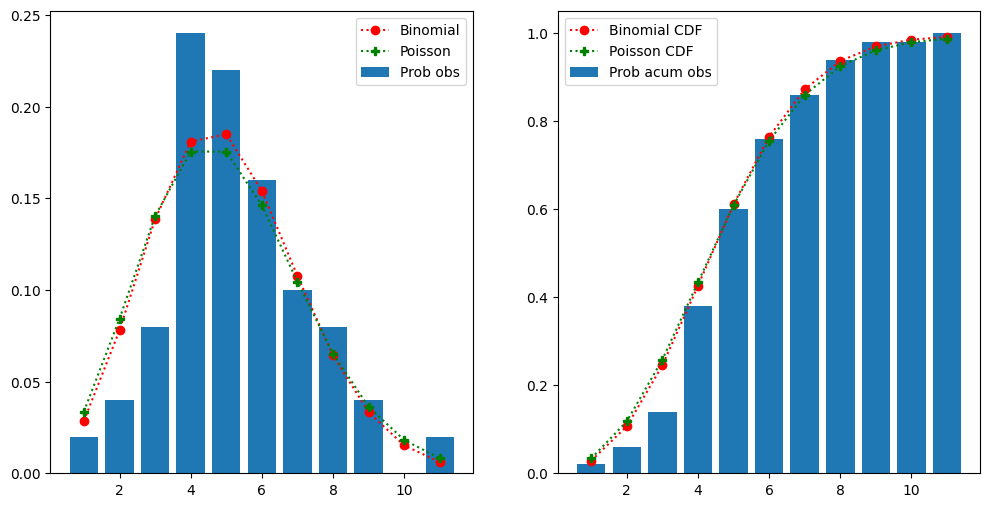

```python
from scipy.stats import binom
n, p = 50, 0.1  # Binomial(n=50, p=0.1)
l = n*p  # Poisson(lambda=n*p=5)

x = x_obs
p_binom = binom.pmf(x, n, p)  # Binomial model
p_poisson = poisson.pmf(x, l)  # Poisson model

# Graficamos
plt.figure(figsize=(12,6))
plt.subplot(1,2,1)  # panel izquierdo
plt.bar(o_data.x_obs, o_data.prob_f_rel, label='Prob obs')
plt.plot(x, p_binom, ':or', label='Binomial')
plt.plot(x, p_poisson, ':Pg', label='Poisson')
plt.legend()

plt.subplot(1,2,2)  # panel derecho
plt.bar(o_data.x_obs, o_data.Fx_obs, label='Prob acum obs')
plt.plot(x, p_binom.cumsum(), ':or', label='Binomial CDF')
plt.plot(x, p_poisson.cumsum(), ':Pg', label='Poisson CDF')
plt.legend()
```

### Prueba de bondad de ajuste

- Revisar: https://nbviewer.org/github/marsgr6/analitica-online/blob/main/statistical_tests.ipynb#chi2ba

```
{'Q_p': 6.831093791242946, 'chi2_critico': 19.67513757268249, 'p-value': 0.8125922301066535, 'decision': 'Do not reject H0'}
```

|  | enlaces | poisson_prob | observed | expected |
| --- | --- | --- | --- | --- |
| 0 | 0 | 0.006738 | 0 | 0.336897 |
| 1 | 1 | 0.033690 | 1 | 1.684487 |
| 2 | 2 | 0.084224 | 2 | 4.211217 |
| 3 | 3 | 0.140374 | 4 | 7.018695 |
| 4 | 4 | 0.175467 | 12 | 8.773368 |
| 5 | 5 | 0.175467 | 11 | 8.773368 |
| 6 | 6 | 0.146223 | 8 | 7.311140 |
| 7 | 7 | 0.104445 | 5 | 5.222243 |
| 8 | 8 | 0.065278 | 4 | 3.263902 |
| 9 | 9 | 0.036266 | 2 | 1.813279 |
| 10 | 10 | 0.018133 | 0 | 0.906639 |
| 11 | 11 | 0.008242 | 1 | 0.412109 |

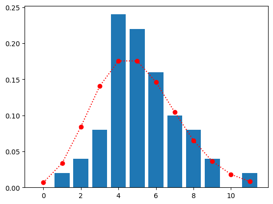

```python
from scipy.stats import chi2
l = 5
x_obs = np.concatenate(([0], x_obs))
observed, expected = np.concatenate(([0], f_obs)), poisson.pmf(x_obs, l)*len(data.Enlaces)

alpha = 0.05
k = len(observed)
df = k - 1

Q_p = ((observed - expected)**2 / expected).sum()
chi2_c = chi2.ppf(1-alpha, df)
decision = {True: "Reject H0", False: "Do not reject H0"}
pvalue = 1-chi2.cdf(Q_p, df)
print({"Q_p": Q_p, "chi2_critico": chi2_c, "p-value": pvalue,
       "decision": decision[Q_p > chi2_c]})
summary = pd.DataFrame({'enlaces': x_obs,
                        'poisson_prob': poisson.pmf(x_obs, l),
                        'observed': observed,
                        'expected':expected})

plt.bar(summary.enlaces, summary.observed/summary.observed.sum(), label='Prob obs')
plt.plot(summary.enlaces, summary.poisson_prob, ':or', label='PMF modelo')

summary
```

```
{'Q_p': 201.23573098014717, 'chi2_critico': 19.67513757268249, 'p-value': 0.0, 'decision': 'Reject H0'}
```

|  | enlaces | poisson_prob | observed | expected |
| --- | --- | --- | --- | --- |
| 0 | 0 | 0.049787 | 0 | 2.489353 |
| 1 | 1 | 0.149361 | 1 | 7.468060 |
| 2 | 2 | 0.224042 | 2 | 11.202090 |
| 3 | 3 | 0.224042 | 4 | 11.202090 |
| 4 | 4 | 0.168031 | 12 | 8.401568 |
| 5 | 5 | 0.100819 | 11 | 5.040941 |
| 6 | 6 | 0.050409 | 8 | 2.520470 |
| 7 | 7 | 0.021604 | 5 | 1.080202 |
| 8 | 8 | 0.008102 | 4 | 0.405076 |
| 9 | 9 | 0.002701 | 2 | 0.135025 |
| 10 | 10 | 0.000810 | 0 | 0.040508 |
| 11 | 11 | 0.000221 | 1 | 0.011048 |

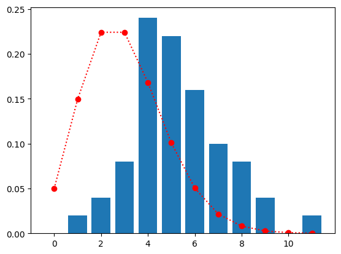

```python
l = 3  # Check the Hypothesis test result, l=3 is not a good estimation for lambda
observed, expected = np.concatenate(([0], f_obs)), poisson.pmf(x_obs, l)*len(data.Enlaces)


alpha = 0.05
k = len(observed)
df = k - 1

Q_p = ((observed - expected)**2 / expected).sum()
chi2_c = chi2.ppf(1-alpha, df)
decision = {True: "Reject H0", False: "Do not reject H0"}
pvalue = 1-chi2.cdf(Q_p, df)
print({"Q_p": Q_p, "chi2_critico": chi2_c, "p-value": pvalue,
       "decision": decision[Q_p > chi2_c]})
summary = pd.DataFrame({'enlaces': x_obs,
                        'poisson_prob': poisson.pmf(x_obs, 3),
                        'observed': observed,
                        'expected':expected})

plt.bar(summary.enlaces, summary.observed/summary.observed.sum(), label='Prob obs')
plt.plot(summary.enlaces, summary.poisson_prob, ':or', label='PMF modelo')

summary
```

### Vea:

- https://www.itl.nist.gov/div898/handbook/eda/eda.htm
- https://www.itl.nist.gov/div898/handbook/eda/section3/eda33.htm
- https://www.itl.nist.gov/div898/handbook/prc/section2/prc211.htm
- https://www.itl.nist.gov/div898/handbook/eda/section3/eda35f.htm

[figure not shown]

Created in Deepnote